# Solution PCA prediction on Breast cancer dataset

Benoit Liquet

# Prediction using PCA

In this question we will use the dataset which contains quantitative information from digitized images of a diagnostic test (fine needle aspirate (FNA) test on breast mass) for the diagnosis of breast cancer. The variables describe characteristics of the cell nuclei present in the image. The mean, standard error and ``worst’’ or largest (mean of the three largest values) of these features were computed for each image, resulting in 30 features. For instance, field 3 is Mean Radius, field 13 is Radius SE, field 23 is Worst Radius.

```r
load("../Breast_cancer.RData")
```

- 80/20 split data

```r
# Set a seed for reproducibility
set.seed(40)

# Determine the number of rows in the dataset
n <- nrow(Breast_cancer_data)

# Create a random sample of indices for the training set (80% of the data)
train_indices <- sample(1:n, size = 0.8 * n)

# Create training and testing sets
train_data <- Breast_cancer_data[train_indices, ]
test_data <- Breast_cancer_data[-train_indices, ]
```

```r
Breast.var_train <- train_data[,-c(1,2)]
```

### PCA with scaled variables

```r
# Perform PCA with scaled variables
pca <- prcomp(Breast.var_train, scale = TRUE)
```

The plot representing the variance explained by the components is called Scree Plot.

```r
library(factoextra)
summary(pca) #variance explained
```

```
Importance of components:
                          PC1    PC2     PC3     PC4     PC5     PC6     PC7
Standard deviation     3.6843 2.3373 1.69694 1.42212 1.29159 1.04742 0.82331
Proportion of Variance 0.4525 0.1821 0.09599 0.06741 0.05561 0.03657 0.02259
Cumulative Proportion  0.4525 0.6346 0.73056 0.79797 0.85358 0.89015 0.91274
                           PC8    PC9    PC10    PC11    PC12   PC13    PC14
Standard deviation     0.67658 0.6318 0.60680 0.53286 0.51713 0.4549 0.37603
Proportion of Variance 0.01526 0.0133 0.01227 0.00946 0.00891 0.0069 0.00471
Cumulative Proportion  0.92800 0.9413 0.95358 0.96304 0.97196 0.9788 0.98357
                          PC15    PC16    PC17    PC18    PC19    PC20    PC21
Standard deviation     0.31427 0.28806 0.25142 0.22388 0.20924 0.17690 0.17081
Proportion of Variance 0.00329 0.00277 0.00211 0.00167 0.00146 0.00104 0.00097
Cumulative Proportion  0.98686 0.98962 0.99173 0.99340 0.99486 0.99590 0.99688
                          PC22    PC23    PC24    PC25    PC26    PC27    PC28
Standard deviation     0.16360 0.14185 0.13557 0.10527 0.08977 0.08118 0.04118
Proportion of Variance 0.00089 0.00067 0.00061 0.00037 0.00027 0.00022 0.00006
Cumulative Proportion  0.99777 0.99844 0.99905 0.99942 0.99969 0.99991 0.99997
                          PC29    PC30
Standard deviation     0.02929 0.01136
Proportion of Variance 0.00003 0.00000
Cumulative Proportion  1.00000 1.00000
```

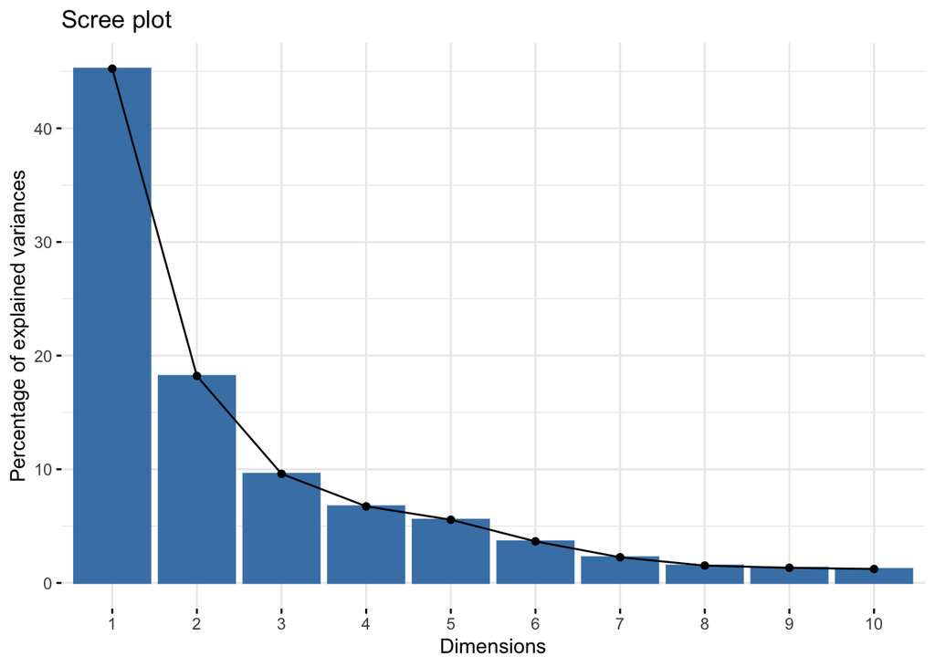

```r
fviz_eig(pca)
```

- using the function that computes eigenvectors and eigenvalues for a matrix.

```r
#first scale the data
data.scaled <- apply(Breast.var_train, 2, scale) #apply scale to columns
#get the covariance matrix
cov.X <- cov(data.scaled)

#Get the eigenvalues and eigenvectors
#of the covariance matrix
ev<- eigen(cov.X)

#The sqrt of the eigenvalues are the std
#deviations of the compontents
sqrt(ev$values)  #equal to pca$sdev
```

```
 [1] 3.68431930 2.33727516 1.69694330 1.42212318 1.29158657 1.04741669
 [7] 0.82330978 0.67657928 0.63175828 0.60679689 0.53285956 0.51712511
[13] 0.45489390 0.37602741 0.31426973 0.28806485 0.25141620 0.22387601
[19] 0.20923563 0.17689533 0.17081469 0.16359998 0.14185253 0.13556845
[25] 0.10527164 0.08976665 0.08118028 0.04117742 0.02929147 0.01135589
```

```r
pca$sdev[1:5]
```

```
[1] 3.684319 2.337275 1.696943 1.422123 1.291587
```

```r
#And the eigenvectors are the principal components.
ev$vector[,1:5] #equal to pca$rotation (up to the sign)
```

```
              [,1]         [,2]         [,3]         [,4]         [,5]
 [1,] -0.217269183 -0.238674212 -0.010346526  0.045071091  0.030966165
 [2,] -0.095393861 -0.062904407  0.042811286 -0.607398652 -0.009478194
 [3,] -0.226013363 -0.218300024 -0.009966942  0.044621393  0.032478018
 [4,] -0.218317052 -0.235860779  0.028525460  0.049884333  0.004993949
 [5,] -0.148354537  0.187565185 -0.072394974  0.127564943 -0.383567901
 [6,] -0.240364630  0.150152227 -0.057583544  0.029935620  0.019458303
 [7,] -0.256842469  0.050419223 -0.010408981  0.009697235  0.072492908
 [8,] -0.259000295 -0.037312016 -0.016945486  0.049070802 -0.051915858
 [9,] -0.144127608  0.189818176 -0.001686347  0.056909025 -0.289987672
[10,] -0.069106588  0.373260625 -0.007490291  0.028731926 -0.048079687
[11,] -0.199059009 -0.109193849  0.289081038  0.077732303 -0.136364456
[12,] -0.008973780  0.070210216  0.368531251 -0.400409728 -0.119335493
[13,] -0.206573606 -0.087897425  0.287883863  0.069847600 -0.086902133
[14,] -0.201130209 -0.156579655  0.233886155  0.092856206 -0.115817565
```

[output cut: 16 more lines]

- We can also use the SVD of the scaled data to get the same results

```r
svd.X <- svd(data.scaled)
svd.X$v[,1:2] # the two first components loading equal to ev$vector[,1:2]
```

```
             [,1]         [,2]
 [1,] 0.217269183  0.238674212
 [2,] 0.095393861  0.062904407
 [3,] 0.226013363  0.218300024
 [4,] 0.218317052  0.235860779
 [5,] 0.148354537 -0.187565185
 [6,] 0.240364630 -0.150152227
 [7,] 0.256842469 -0.050419223
 [8,] 0.259000295  0.037312016
 [9,] 0.144127608 -0.189818176
[10,] 0.069106588 -0.373260625
[11,] 0.199059009  0.109193849
[12,] 0.008973780 -0.070210216
[13,] 0.206573606  0.087897425
[14,] 0.201130209  0.156579655
```

[output cut: 16 more lines]

```r
svd.X$d # equal to sqrt((n-1)*ev$values)
```

```
 [1] 78.5028073 49.8009664 36.1572387 30.3015707 27.5201911 22.3175962
 [7] 17.5424884 14.4160613 13.4610479 12.9291887 11.3537855 11.0185272
[13]  9.6925497  8.0121197  6.6962317  6.1378771  5.3569942  4.7701879
[19]  4.4582413  3.7691575  3.6395956  3.4858700  3.0224909  2.8885944
[25]  2.2430518  1.9126828  1.7297305  0.8773786  0.6241214  0.2419631
```

```r
n <- dim(data.scaled)[1]
sqrt((n-1)*ev$values)
```

```
 [1] 78.5028073 49.8009664 36.1572387 30.3015707 27.5201911 22.3175962
 [7] 17.5424884 14.4160613 13.4610479 12.9291887 11.3537855 11.0185272
[13]  9.6925497  8.0121197  6.6962317  6.1378771  5.3569942  4.7701879
[19]  4.4582413  3.7691575  3.6395956  3.4858700  3.0224909  2.8885944
[25]  2.2430518  1.9126828  1.7297305  0.8773786  0.6241214  0.2419631
```

- We can visualize the samples on the first two components

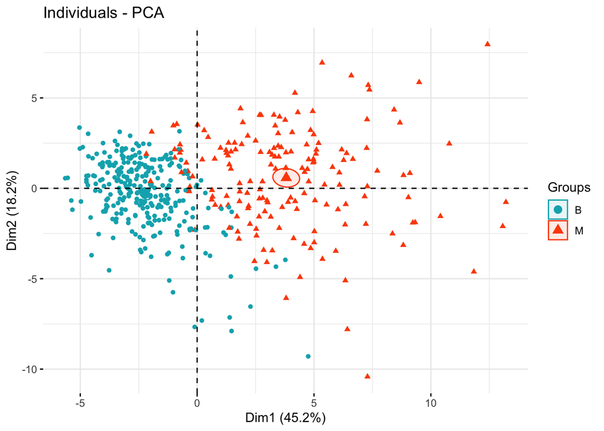

```r
groups  <-  train_data$diagnosis

fviz_pca_ind(pca,
             col.ind = groups, # color by groups
             palette = c("#00AFBB",  "#FC4E07", "blue", "red"),
             addEllipses = TRUE, # Concentration ellipses
             ellipse.type = "confidence",
             legend.title = "Groups",
             repel = FALSE,
             label="none",
             axes=c(1,2)
             )
```

```r
library(caret)
trctrl <- trainControl(method = "repeatedcv",
                       number = 10,
                       preProcOptions =list(pcaComp = 3),
                       classProbs = TRUE,
                       summaryFunction = twoClassSummary)

breast.glm <- caret::train(diagnosis ~ .,
                   data = train_data[,-1],
                   method = "glm",
                   family=binomial,
                   trControl = trctrl,
                   preProcess=c("center", "scale", "pca"), #uses PCA
                   metric="ROC")

breast.glm
```

```
Generalized Linear Model

455 samples
 30 predictor
  2 classes: 'B', 'M'

Pre-processing: centered (30), scaled (30), principal component
 signal extraction (30)
Resampling: Cross-Validated (10 fold, repeated 1 times)
Summary of sample sizes: 410, 410, 409, 409, 409, 409, ...
Resampling results:

  ROC        Sens       Spec
  0.9917574  0.9512315  0.9283088
```

The prediction accuracy is excellent with three components. We can get the coefficients for these components but they do not have an obvious interpretation.

```r
summary(breast.glm)
```

```
Call:
NULL

Coefficients:
            Estimate Std. Error z value Pr(>|z|)
(Intercept)  -1.0731     0.3235  -3.317 0.000909 ***
PC1           2.4122     0.3799   6.349 2.17e-10 ***
PC2           1.4445     0.2818   5.125 2.97e-07 ***
PC3           0.7200     0.2073   3.474 0.000513 ***
---
Signif. codes:  0 '***' 0.001 '**' 0.01 '*' 0.05 '.' 0.1 ' ' 1

(Dispersion parameter for binomial family taken to be 1)

    Null deviance: 599.276  on 454  degrees of freedom
Residual deviance:  93.245  on 451  degrees of freedom
AIC: 101.24

Number of Fisher Scoring iterations: 9
```

We check this result using glm function:

```r
data.glm <- data.frame(train_data$diagnosis,pca$x[,1:3])
colnames(data.glm) <- c("diagnosis","PC1","PC2","PC3")

data.glm$diagnosis <- factor(data.glm$diagnosis)
model.glm <- glm(diagnosis ~ PC1+PC2+PC3,family=binomial(),data=data.glm)
summary(model.glm)
```

```
Call:
glm(formula = diagnosis ~ PC1 + PC2 + PC3, family = binomial(),
    data = data.glm)

Coefficients:
            Estimate Std. Error z value Pr(>|z|)
(Intercept)  -1.0731     0.3235  -3.317 0.000909 ***
PC1           2.4122     0.3799   6.349 2.17e-10 ***
PC2           1.4445     0.2818   5.125 2.97e-07 ***
PC3           0.7200     0.2073   3.474 0.000513 ***
---
Signif. codes:  0 '***' 0.001 '**' 0.01 '*' 0.05 '.' 0.1 ' ' 1

(Dispersion parameter for binomial family taken to be 1)

    Null deviance: 599.276  on 454  degrees of freedom
Residual deviance:  93.245  on 451  degrees of freedom
AIC: 101.24

Number of Fisher Scoring iterations: 9
```

- Project the test data on the lower dimensional space (i.e, using some PCs)

```r
# Select the same features from the test data (excluding the first two columns)
Breast.var_test <- test_data[,-c(1,2)]
# Apply PCA to the test data using the same PCA model.
pca_test <- predict(pca, newdata = Breast.var_test)
pca_test <- pca_test[,1:3]
colnames(pca_test)[1:3] <- c("PC1","PC2","PC3")
newdatatest <- data.frame(pca_test)
dim(newdatatest)
```

```
[1] 114   3
```

```r
# Predict probabilities using the GLM model
predicted_probs <- predict(model.glm, newdata = newdatatest, type = "response")
length(predicted_probs)  # Should return 114
```

```
[1] 114
```

- Convert probabilities to binary predictions

```r
predicted_classes <- ifelse(predicted_probs > 0.5, "M", "B")
```

- Create the confusion matrix

```r
confusion_matrix <- table(Predicted = predicted_classes, Actual = test_data$diagnosis)
# Print the confusion matrix
print(confusion_matrix)
```

```
         Actual
Predicted  B  M
        B 69  5
        M  1 39
```

- We will plot the ROC curve and compute the AUC metric

```r
library(ROCit)
library(ROCR)
pr_full = prediction(predicted_probs, test_data$diagnosis)
perf_full = performance(pr_full, measure = "tpr", x.measure = "fpr")

auc1 = performance(pr_full, measure = "auc")
auc1 = auc1@y.values[[1]]

print(paste("AUC full test", signif(auc1,digits=4)))
```

```
[1] "AUC full test 0.9831"
```

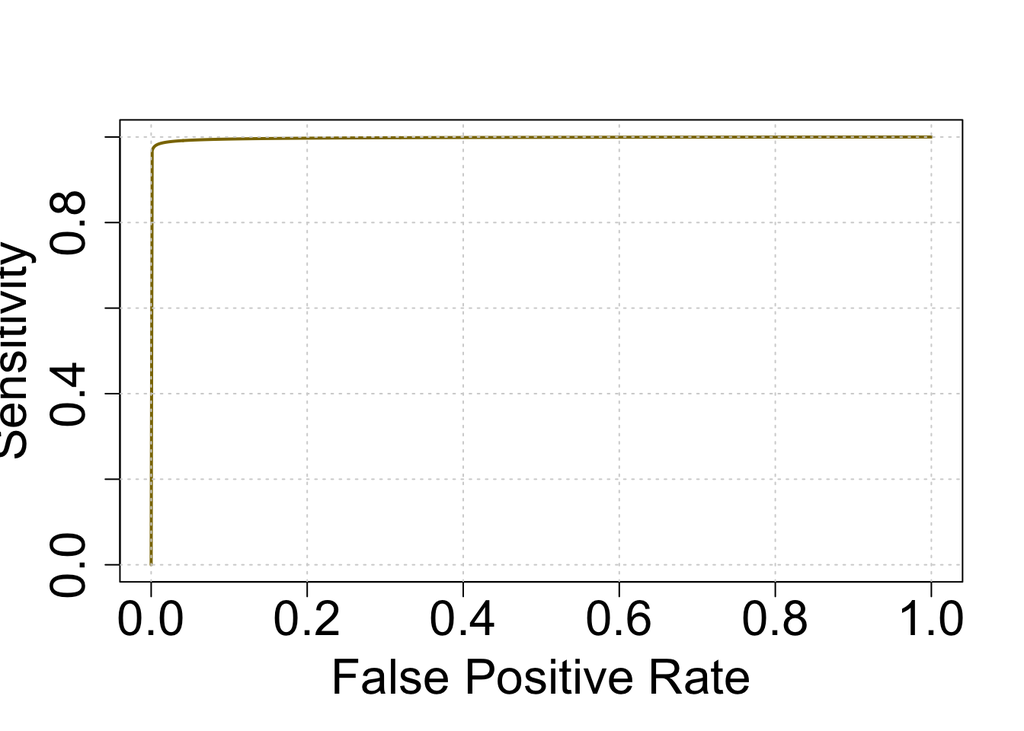

```r
r3=rocit(predicted_probs, test_data$diagnosis, method = "bin")
plot(r3$TPR~r3$FPR, type = "l", xlab = "False Positive Rate", lwd = 2,
     ylab = "Sensitivity", col= "gold4",cex.lab=2,cex.axis = 2)
grid()
```

- Let compare with a model using only the first PC

```r
model.glm.1pc <- glm(diagnosis ~ PC1,family=binomial(),data=data.glm)
#summary(model.glm.1pc)
```

```r
# Predict probabilities using the GLM model
predicted_probs.1pc <- predict(model.glm.1pc, newdata = newdatatest, type = "response")
predicted_classes.1pc <- ifelse(predicted_probs.1pc > 0.5, "M", "B")
confusion_matrix.1pc <- table(Predicted = predicted_classes.1pc, Actual = test_data$diagnosis)
# Print the confusion matrix
print(confusion_matrix.1pc)
```

```
         Actual
Predicted  B  M
        B 65  8
        M  5 36
```

- ROC curve

```r
library(ROCit)
pr_full.1pc = prediction(predicted_probs.1pc, test_data$diagnosis)
perf_full.1pc = performance(pr_full.1pc, measure = "tpr", x.measure = "fpr")

auc1pc = performance(pr_full.1pc, measure = "auc")
auc1pc = auc1pc@y.values[[1]]

print(paste("AUC 1 PC", signif(auc1pc,digits=4)))
```

```
[1] "AUC 1 PC 0.9578"
```

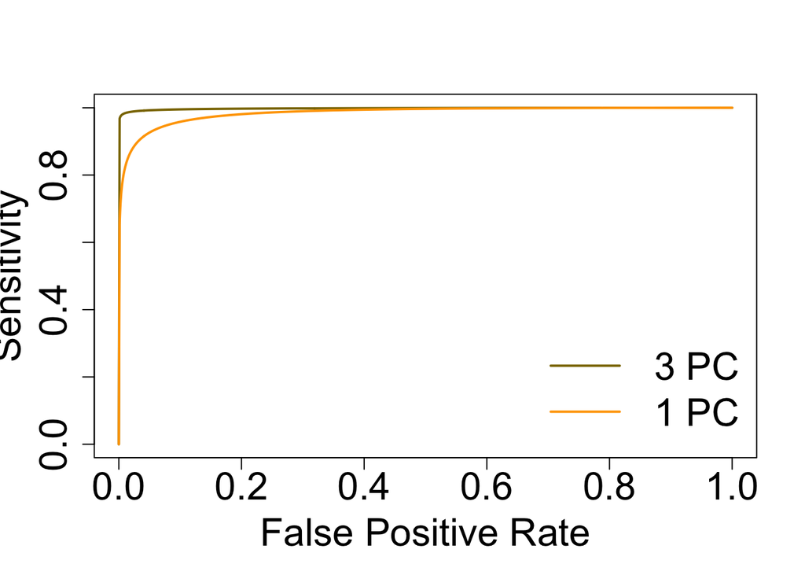

```r
r1=rocit(predicted_probs.1pc, test_data$diagnosis, method = "bin")
plot(r3$TPR~r3$FPR, type = "l", xlab = "False Positive Rate", lwd = 2,
     ylab = "Sensitivity", col= "gold4",cex.lab=2,cex.axis = 2)
lines(r1$TPR~r1$FPR, lwd = 2, col = "orange")
legend("bottomright", c("3 PC", "1 PC"), cex=2,
       lwd = 2, col = c("gold4",
                        "orange"), bty = "n")
```